# DW-NOMINATE and Congressional Polarization

The widest gap since Reconstruction, and a chamber nobody redistricts

Democracy’s Data

Last updated September 13, 2026 at 10:53a EDT

Congress is more divided than it has ever been. You have read that sentence in a newspaper and heard it from a member of Congress. This brief asks how anybody could know. Nobody can watch a legislator’s opinions, and nobody can put nine hundred million dollars of campaign rhetoric on a ruler. What the country has instead is a complete record of how every member voted, and the question is whether a number worth arguing about can be built from that alone.

The answer matters beyond bookkeeping. The American system was built on the assumption that the parties would overlap. Separated powers, two chambers, the filibuster and the committee system all need cross-party coalitions to produce anything. When the parties are internally unified and far apart, those features stop working as checks and start working as blockages.

So the question splits in two. Can polarization be measured from votes and nothing else, and if it can, is the country’s favourite explanation for it right? The answer to the first is yes. The answer to the second is no, and the file says so plainly.

## The test

The measure is DW-NOMINATE, a score placed on every member of the House and Senate from 1879 to 2025 according to how often they voted with and against every other member. The initials stand for a phrase only its authors use, Dynamic Weighted Nominal Three-step Estimation; what matters is that the number is computed by a method, not recorded by a clerk.[^1] It is published by [Voteview](https://voteview.com), a project run at UCLA by Jeffrey Lewis, Keith Poole, Howard Rosenthal and their colleagues, and downloadable by anyone, with no account to open, at https://voteview.com/data. It arrives as one file, `HSall_members.csv`: one row per member per Congress, carrying a coordinate on a line running from about −1 to +1.

The coordinate is manufactured, and the roll-call chapter says what it is manufactured from. Congress records how every member voted on every recorded vote, and for most of two centuries records nothing at all about what the vote was about. A scaling method reads that grid of agreement and disagreement, then arranges members on a line so that members who vote together sit near each other. Nobody reads a bill, and nobody labels a policy as liberal or conservative. That the line falling out of the arithmetic looks like left and right is a finding rather than an assumption, and it is the most remarkable thing about the method. The method also makes choices along the way — how many dimensions to allow, how far a member’s position may drift over a career, what to do with the votes a member missed — and those choices are inside every chart built on the scores, including every chart below.

This file is the right evidence here for a reason that is easy to state and hard to satisfy. The question is about change across 146 years, and comparability over that span cannot be added afterwards. Every Congress is scaled in one estimation — the whole record of votes since 1789 goes into the method at once — so a coordinate from 1879 and a coordinate from 2025 sit on the same ruler. Nothing else in American politics does that. The cost is that no government agency produces the file, and if the project ever stopped there is no other file in the world that would do its job.

## The data

One row is one member in one Congress. `bioname` is the name, `state` and `district_code` the seat, and `party` the party. `congress` is the numbered Congress and `year` the calendar year it convened. `dim1` is the first dimension, the left–right coordinate: negative is liberal, positive is conservative. `dim2` is a second dimension, a second coordinate the method allows for whatever disagreement the first line cannot capture, which for most of the twentieth century carried the split over race and region and now barely moves.[^2]

| Congress | Year | Chamber | State | Member | Party | Dim 1 | Dim 2 |
| --- | --- | --- | --- | --- | --- | --- | --- |
| 119 | 2025 | House | TX | GARCIA, Sylvia | Democrat | -0.764 | 0.311 |
| 119 | 2025 | House | TX | TURNER, Sylvester | Democrat | -0.746 | 0.666 |
| 119 | 2025 | House | MP | KING-HINDS, Kimberlyn | Republican | 0.163 | -0.043 |
| 119 | 2025 | House | GA | MCCORMICK, Rich | Republican | 0.891 | 0.454 |
| 119 | 2025 | House | NC | HARRIGAN, Pat | Republican | 0.972 | 0.234 |

Take the two ends of that table. GARCIA, Sylvia sits at -0.764 and HARRIGAN, Pat at 0.972. The method placed them that far apart because, across the recorded votes both answered, they were on opposite sides far more often than two members picked at random would be; a member whose votes split between the two sides lands between them, and one who voted with each of them about equally often lands near the middle. No party label, district or speech went into the placement, only the votes, and the same is true of every coordinate in the file.

That table is the download reduced by five decisions, and each one is a decision rather than a cleanup. Presidents are dropped. They carry coordinates too, but theirs are estimated from announced positions rather than from roll calls, so folding them into a chamber median would average two different measurements together. Only the two major parties are kept, which means every independent in American history leaves, including the ones who caucus with a party and vote with it. Members with no coordinate are dropped rather than carried as blanks, and those are people who served too briefly for the model to place them.

Two more decisions set the frame of every figure below. `year` is computed from the Congress number rather than read, because the download carries no year at all: the first Congress met in 1789 and a new one begins every two years. The series then starts at the 46th Congress, in 1879, on the judgment that earlier party labels do not mean the same thing and rest on far fewer recorded votes.

| Quantity | Value |
| --- | --- |
| Member-Congress records | 38,643 |
| House records | 31,317 |
| Senate records | 7,326 |
| Congresses covered | 46th–119th |
| Years covered | 1879–2025 |

Note what a row is not. It is not a survey answer, a statement of belief, or anything the member said out loud. It is a position estimated from votes cast, and it exists only because other members voted too.

> **Before you read on, write down a number.** The most common explanation for congressional polarization is gerrymandering: safe districts produce members who fear only a primary challenge and therefore drift to the extremes. Now consider the Senate. Senators represent whole states, and **nobody draws a state line.** If districting is the engine, the Senate should have polarized markedly *less* than the House. **How much less?** Half as much, a quarter, not at all — commit to a fraction before you look.

## What it says about democracy

Take the median member of each party in each Congress — line the party’s members up by their `dim1` and take the one in the middle — and subtract one median from the other. That distance is what this brief means by polarization, and it is the entire measurement, arithmetic anybody can check. In the 119th House the median of the 222 Democrats sits at -0.396 and the median of the 227 Republicans at 0.530; subtract, and the distance is 0.925.

| Congress | Year | Median Democrat | Median Republican | Distance |
| --- | --- | --- | --- | --- |
| 90 | 1967 | -0.343 | 0.241 | 0.584 |
| 100 | 1987 | -0.320 | 0.346 | 0.666 |
| 110 | 2007 | -0.379 | 0.426 | 0.805 |
| 119 | 2025 | -0.396 | 0.530 | 0.925 |

**The gap between the House parties was 0.584 in 1967. It is 0.925 now**, the widest in a series reaching back to 1879. The sentence everybody repeats is true on this measure, and it is not close.

Two exceptions matter more than the headline. The narrowest Congress on record is 0.498, in 1947, in the middle of the century that produced almost all of our intuitions about how Congress is supposed to work. The 1890s then reached 0.852, in 1895, not far below today. The shape of the series is a U, and the bipartisan era sits at the bottom of it. Nobody can want the mid-century comity without the party system that produced it, which included conservative Southern Democrats and ended with the civil-rights realignment.

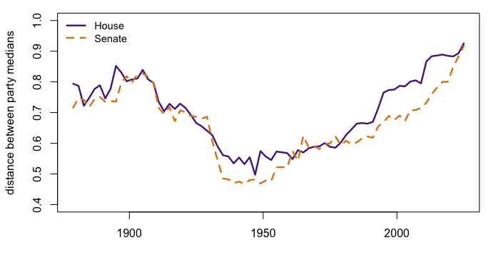

**Figure 1. The distance between the party medians, House and Senate, in every Congress from 1879 to 2025.** A line over time fits this question because the claim is a claim about change. Two lines rather than one, because the comparison between the chambers *is* the test: the House is redistricted every ten years and the Senate has never been redistricted at all. If partisan districting were the engine, the Senate line should be visibly flatter than the House one. Hover for both values at any year.

Now the number you wrote down.

| Chamber | Gap in that year | Gap now | Change |
| --- | --- | --- | --- |
| House | 0.584 | 0.925 | +0.342 |
| Senate | 0.587 | 0.917 | +0.331 |

**They are nearly identical.** The House went from 0.584 to 0.925, a change of 0.342. The Senate went from 0.587 to 0.917, a change of 0.331. Two chambers, one drawn by partisan legislatures every ten years and one never drawn at all, polarized in near-lockstep over sixty years.

That is real evidence against the districting explanation, and it is worth sitting with, because gerrymandering is the story most people arrive holding. Do not overclaim in the other direction either. The result shows that districting is not sufficient to explain polarization. It does not show that districting has no effect. Both chambers face primary electorates, national donors and the same media environment, and shared causes like those would produce exactly this pattern.

The middle emptied in both chambers as well. The 107th Congress, in 2001, was the last in which a single Republican in the House sat to the left of a single Democrat. There were 2 of them, and since then the count has been zero every time. The Senate followed one Congress later.

Zero overlap is not itself new, and it happened repeatedly between 1879 and 1919. What is unprecedented is zero overlap alongside a gap this wide. Two measures tell two different stories, and only their combination is new.

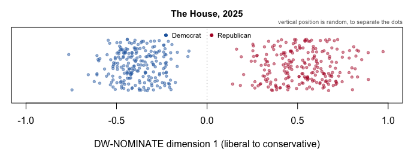

**Figure 2. The House of 2025, one dot per member.** Position along the axis is the member’s first-dimension coordinate; vertical position is random and carries no information, so that overlapping members can be told apart. Two clouds, and nothing between them. The separation is not something anybody put into the method, which never saw a party label. It is what the voting produced.

The two parties both moved, and they did not move equally. Since 1967 the Democratic median in the House has moved 0.053 to the left, and the Republican median 0.289 to the right, which is 5.5 times as far. This is the finding called asymmetric polarization, and it is among the most contested claims in the study of Congress.[^3] The argument is not about the arithmetic. It is about what the scale is anchored to, which the next section takes up.

## What this brief cannot tell you

The scale is relative to the votes that were actually held, and that is the limit built into the file. If Congress stops voting on some issues and starts voting on others, a member who never changed their mind can move on the scale. Bateman, Clinton and Lapinski (2017) rebuilt the estimates holding the policy content of votes fixed, and found today’s parties less divided than the standard series suggests.[^4] “Republicans moved right” and “the agenda moved and Republicans stood still” produce the same picture in this data, and nothing inside it can tell them apart.

Nothing here is a member changing their mind. In this file every member carries one pair of coordinates for a whole career. Of the 6,936 House members here, only 8 have more than one value of `dim1`, and those are people who left Congress and later came back. Every movement in a party median is somebody arriving or leaving.

The file attaches no uncertainty to a coordinate, so two members a few hundredths apart are not actually distinguishable. It also cannot separate a sincere vote from a strategic one, because a recorded vote is an act rather than a preference. And all of it is 535 people. Whether the public polarized alongside its legislature is a different question, and the roll calls cannot speak to it.

## What you should have learned

- The distance between the House party medians has risen from 0.584 in 1967 to 0.925 today, the widest in a series that reaches back to 1879.
- The series is a U rather than a slope: its narrowest Congress is 0.498, in 1947, and the 1890s reached 0.852.
- The Senate went from 0.587 to 0.917 over the same span, in a chamber whose boundaries nobody draws, so partisan districting cannot be the main engine of polarization.
- A DW-NOMINATE coordinate is manufactured from the pattern of who voted with whom. It says who a member voted with, never what they voted for.
- The scale is relative to the agenda, and no party median here moves because somebody changed their mind: only 8 of 6,936 House members in the file have more than one coordinate.

## Extensions

None of these is answered above, and every one can be answered from the table the Sources section hands over.

- `nominate_members.csv` has `dim1`, `party` and `year` for every member of every Congress. Average `dim1` inside each party in each year and plot both lines. Which party moved, and when?
- The same file has `chamber`. Do the party-median calculation separately for `House` and `Senate` rows in the same `congress`. Does the chamber that draws no districts look different from the one that does?
- `dim2` is the second dimension. Compute its spread across House members in each `year`. When did it stop mattering, and what issue left American politics with it?
- `state` and `bioname` name the seat and the person. Filter to one state and follow its delegation’s `dim1` across Congresses. Is the state moving, or are its members being replaced?

Two stretch ideas point past the spreadsheet. Voteview also publishes coordinates re-estimated inside each Congress rather than fixed across a career, the Nokken-Poole columns of the same members file; download those columns and redo the party medians, then ask whether the widening changes shape once members are allowed to move. And Boris Shor and Nolan McCarty publish comparable scores for all fifty state legislatures — pick your own and ask whether it polarized on the same timetable as Congress.

## Sources

**Data**

- **Voteview** — Lewis, J. B., Poole, K., Rosenthal, H., Boche, A., Rudkin, A. and Sonnet, L., *Congressional Roll-Call Votes Database*. `HSall_members.csv`. https://voteview.com/static/data/out/members/HSall_members.csv, from https://voteview.com; every file the project publishes is listed at https://voteview.com/data. Every member of the House and Senate from the 46th Congress (1879) to the present, with DW-NOMINATE coordinates.

**Academic literature**

- Poole, K. T. and Rosenthal, H. (1985). “A Spatial Model for Legislative Roll Call Analysis.” *American Journal of Political Science* 29(2): 357–384. https://doi.org/10.2307/2111172
- Poole, K. T. and Rosenthal, H. (1997). *Congress: A Political-Economic History of Roll Call Voting.* Oxford University Press.
- McCarty, N., Poole, K. T. and Rosenthal, H. (2006). *Polarized America: The Dance of Ideology and Unequal Riches.* MIT Press.
- Bateman, D. A., Clinton, J. D. and Lapinski, J. S. (2017). “A House Divided? Roll Calls, Polarization, and Policy Differences in the U.S. House, 1877–2011.” *American Journal of Political Science* 61(3): 698–714. doi:10.1111/ajps.12281

**The data itself**

Every figure above is drawn from this table. It is plain CSV, it opens in a spreadsheet, and it is yours to take further.

`nominate_members.csv`

Rebuild this data yourself, with an AI assistant

```
I want to rebuild a public dataset from its original source, without any
starting files. Please do the following and show your work.

THE SOURCE. Voteview, the congressional roll-call database maintained
by Lewis, Poole, Rosenthal and colleagues. One CSV, about 6 MB, no
account or key:
https://voteview.com/static/data/out/members/HSall_members.csv
Each row is one member of Congress in one Congress — a person who
served ten terms is ten rows — carrying their DW-NOMINATE coordinates,
a left-right position estimated purely from how they voted relative to
everyone else. Nobody read the bills; the scale falls out of the
pattern of agreement alone. Presidents are in the file too.

WHAT TO BUILD.
1. A member table filtered four ways: House and Senate only (this
   drops the presidents), the two major parties only (party codes 100
   and 200), rows that actually carry a first-dimension score, and the
   46th Congress (1879) onward — before that, the party system is too
   different for a Democrat-Republican comparison to hold.
2. From the House rows, each party's median first-dimension score in
   each Congress, and the gap between the medians — the standard
   polarization series, computed rather than copied from anywhere.

CHECK YOUR WORK. The copy this book used was downloaded in August 2026.
If your rebuild matches it, you should find:
- 38,643 rows after the four filters
- Congresses 46 through 119
Voteview re-estimates the whole file as new votes arrive, so a member
seated since then adds a row and every coordinate can shift slightly.
One row more is the file being alive, not a mistake.
```

[^1]: The method is Keith T. Poole and Howard Rosenthal, “A Spatial Model for Legislative Roll Call Analysis,” *American Journal of Political Science* 29, no. 2 (1985): 357–384, https://doi.org/10.2307/2111172; the current estimates and their documentation are described at https://voteview.com/about.
[^2]: The book-length account of both dimensions is Keith T. Poole and Howard Rosenthal, *Congress: A Political-Economic History of Roll Call Voting* (Oxford University Press, 1997).
[^3]: The claim is set out in Nolan McCarty, Keith T. Poole and Howard Rosenthal, *Polarized America: The Dance of Ideology and Unequal Riches* (MIT Press, 2006), and disputed in the paper the next section cites.
[^4]: David A. Bateman, Joshua D. Clinton and John S. Lapinski, “A House Divided? Roll Calls, Polarization, and Policy Differences in the U.S. House, 1877–2011,” *American Journal of Political Science* 61, no. 3 (2017): 698–714, doi:10.1111/ajps.12281.